# PRÁCTICA 2: MEDIDA DE TIEMPOS PEQUEÑOS

**Autor responsable:** Víctor Mula Navarro.

**Autores**: Pablo Corbalán de Concepción y Víctor Mula Navarro.

**Grupo:** G4 - DTIE

**Fecha del informe:** 19/02/2026

## INFORMACIÓN GENERAL DEL LABORATORIO

**Fecha de realización de la práctica:** 12/02/2026

**Temperatura:** 21.7ºC

**Humedad relativa:** 42%

**Presión:** 1024.9 HPa

## CARGA DE LIBRERÍAS EN PYTHON

```python
import numpy as np
import math
import matplotlib.pyplot as plt
from __future__ import print_function
from scipy import stats
from scipy.optimize import curve_fit
from scipy.stats import t
```

## 1. INTRODUCCIÓN Y OBJETIVOS

Un diapasón es un instrumento con forma de horquilla que vibra a una frecuencia dada cuando es golpeado de la manera adecuada contra una superficie. Gracias al programa "Audacity" y los dispositivos de grabación adecuados, somos capaces de recoger las ondas que emite el diapasón al vibrar y extraer información sobre ellas. De esta forma, podemos hallar de manera experimental la velocidad del sonido en el material del que está hecho el diapasón, la frecuencia con la que vibra y su módulo de Young. En particular, trabajaremos con diapasones hechos de aluminio.

Por tanto, esta práctica tiene como objetivos hacer uso del programa "Audacity" para estudiar las características de las ondas armónicas emitidas por la vibración de los diapasones. En particular, buscaremos conocer:

- La frecuencia del diapasón.
- El módulo de Young del aluminio.
- La velocidad del sonido en el diapasón.

Por último, se estudiará el espectro de Fourier de la onda. Esto es, las frecuencias que componen la onda y en qué amplitud y fase aparecen. Cualquier onda se puede representar como suma de senos, cosenos y exponenciales complejas y tiene asociadas varias frecuencias. En este experimento, estudiaremos únicamente la frecuencia fundamental de cada onda emitida en la vibración de los diapasones.

## 2. PROCEDIMIENTO Y MONTAJE EXPERIMENTAL

Como se ha mencionado en la introducción, un diapasón vibra a una cierta frecuencia dada. Cada uno de ellos tiene una frecuencia nominal inscrita en su cuerpo. Sin embargo, también podemos hallar dicha magnitud gracias a la teoría de Euler-Bernoulli sobre ondas, la cual nos da la siguiente expresión para la frecuencia:

$$ f = 0.1615 \cdot v_s \cdot \frac{d}{l^2} \tag{1}$$

siendo $v_s$ la velocidad del sonido en el diapasón, $d$ la anchura de sus brazos y $l$ la longitud de los brazos diapasón. La anchura y la longitud de los brazos del diapasón se medirá con la ayuda de un pie de rey. Por otro lado, conocemos:

$$ E = v_s^2 \cdot \rho \tag{2}$$

donde $E$ es el módulo de Young del material y $\rho$, su densidad. Asumiendo que los diapasones son de aluminio, tendrán por tanto una densidad de $2.698 \frac{g}{cm^3}$ (ver Bibliografía).

Mediante una tarjeta de sonido, se conectará un micrófono a un ordenador y se recogerán las vibraciones del diapasón a través de la aplicación "Audacity". El programa nos posibilita estudiar la onda en profundidad. En particular, elegiremos un intervalo de tiempo ($\Delta t$) y contaremos cuántas veces se repite la onda ($N$). De esta forma, podremos estimar el periodo de la onda ($T$):

$$ T = \frac{\Delta t}{N} \tag{3}$$

Así estimaremos de manera experimental la frecuencia con la que vibra el diapasón. La llamaremos frecuencia medida y tendrá la siguiente expresión:

$$ f_{medida} = \frac{1}{T} = \frac{N}{\Delta t} \tag{4}$$

Una vez anotados los datos pertinentes, elegiremos una porción de onda mayor y, con la opción de trazar espectro en el programa, podremos obtener el valor pico correspondiente a la frecuencia fundamental de vibración de la onda. Nos referiremos a esta frecuencia como $f_{Fourier}$.

El procedimiento anterior se realizará para dos diapasones de frecuencia nominal distinta. No obstante, disponemos de información relativa a 20 diapasones, por tanto, se procederá a hacer un ajuste por mínimos cuadrados de la ecuación ($1$), donde identificaremos la variable de control $x = 0.1615 \cdot \frac{d}{l^2}$, la variable de salida $y = f$ y la ordenada en el origen $b \approx 0$. La pendiente de esta recta será el valor de $v_s$ en el aluminio.

### 2.1 INSTRUMENTOS

Los instrumentos utilizados para la realización de este experimento han sido los siguientes:

- **Pie de rey:** De resolución $0.05 mm$.
- **Tarjeta de sonido con micrófono externo**
- **Ordenador portátil**, en particular, del programa "Audacity".
- **Diapasones de aluminio**.

## 3. RESULTADOS

### 3.1 MEDIDAS PARTICULARES DE DOS DIAPASONES

A continuación, se recogen en una tabla las medidas de las magnitudes tomadas para dos diapasones: uno asociado a la nota musical Mi (E) y el otro, a Sol (G).

| Diapasón | $f_{nominal}$ (Hz) | N | $\Delta t$ | $f_{Fourier}$ (Hz) | $d$ (mm) | $l$ (mm) |
| --- | --- | --- | --- | --- | --- | --- |
| 1 (G) | 384 | 19 | 0.050 | 378 | 6.00 | 114.00 |
| 2 (E) | 320 | 9 | 0.028 | 307 | 6.00 | 120.50 |

#### Cálculo de las frecuencias medidas

Procedemos al cálculo de las frecuencias medidas medias a partir de los datos tomados haciendo uso de la ecuación ($4$):

$$ \overline{f_{{medida}_{1}}} = \frac{19}{0.050} = 380.00000 Hz $$ $$ \overline{f_{{medida}_{2}}} = \frac{9}{0.028} = 321.42857 Hz $$ Con su respectiva incertidumbre, proveniente de la resolución al medir intervalos temporales en Audacity. Si asumimos que audacity emplea una distribución uniforme en la gestión de sus tiempos, y expresando la incertidumbre con dos cifras significativas:

$$u_B(f_{medida_1}) = u_B(f_{medida_2}) = \frac{\Delta}{\sqrt{12}} = 0.00029 Hz$$

Como además la incertidumbre tipo A es nula, pues hemos tomado únicamente una medida experimental, la incertidumbre típica combinada coincidirá con la incertidumbre tipo B. Así:

$$\boxed{f_{medida_1} = \overline{f_{{medida}_{1}}} \pm u_{f_{medida_1}} = 380.00000 \pm 0.00029 \text{ Hz}\text{ ; } f_{medida_2} = \overline{f_{{medida}_{2}}} \pm u_{f_{medida_2}} = 321.42857 \pm 0.00029 \text{ Hz}}$$

Se ha capturado la onda sonora generada por cada diapasón. Durante la inspección de los espectros de frecuencia, se ha observado una presencia notable de ruido de fondo. Este fenómeno es entendible entendido en el contexto del Laboratorio, no aislado acústicamente. A continuación se muestra la onda sonora generada por el diapasón de nota G:

[figure not shown]

Así como la onda generada por el diapasón de nota E:

[figure not shown]

Si decidimos, por ejemplo, estudiar la naturaleza de la onda G vemos claramente una onda modulada. La frecuencia no es puramente armónica sino que viene modulada por la influencia de una segunda amplitud. En general estas ondas vienen descritas por una ecuación de la forma:

$$y(t) = [A_c + A_m \cos(\omega_m t)] \cdot \cos(\omega_c t)$$

[figure not shown]

#### Cálculo de las frecuencias por análisis de Fourier

Las frecuencias mostradas en la anterior tabla han sido calculadas con la herramienta de análisis de Fourier del programa Audacity. A continuación se muestra el análisis de las frecuencias de Fourier para los diapasones G y E:

[figure not shown]

#### 3.1.1 GRÁFICAS AUDACITY

Exportamos un archivo `.txt` que recabe una tabla de amplitud frente a tiempo y lo graficamos. Las gráficas se corresponden con el diapasón asociado a la nota musical E. Apreciamos que el gráfico obtenido tiene una forma periódica aunque discreta, al tratarse de una representación de un número finito de instantes de tiempo.

```python
valores_eje_x = np.loadtxt('E.txt', usecols=0)
valores_eje_y = np.loadtxt('E.txt', usecols=1)
```

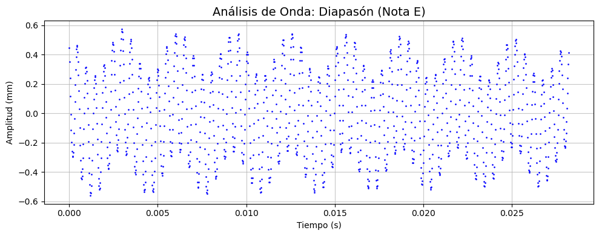

```python
plt.figure(figsize=(10, 4))
plt.plot(valores_eje_x, valores_eje_y, 'o', markersize=1, color='blue', alpha=0.9)

plt.title("Análisis de Onda: Diapasón (Nota E)", fontsize=14)
plt.xlabel("Tiempo (s)")
plt.ylabel("Amplitud (mm)")
plt.grid(True, alpha=0.7)
plt.tight_layout()
plt.show()
```

Para observar con claridad la estructura periódica de una onda modulada, se ha optado por realizar un zoom temporal, evitando así la saturación visual de los ciclos y permitiendo una medición más exacta del periodo.

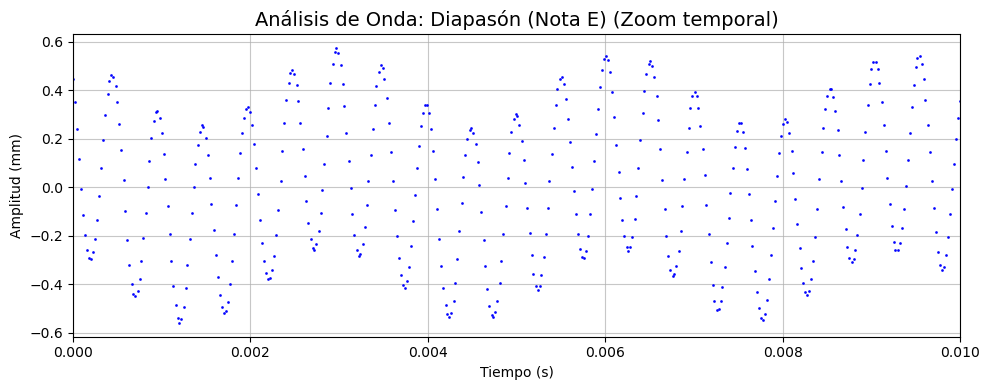

```python
plt.figure(figsize=(10, 4))
plt.plot(valores_eje_x, valores_eje_y, 'o', markersize=1, color='blue', alpha=0.9)
plt.xlim(0, 0.01)
plt.title("Análisis de Onda: Diapasón (Nota E) (Zoom temporal)", fontsize=14)
plt.xlabel("Tiempo (s)")
plt.ylabel("Amplitud (mm)")
plt.grid(True, alpha=0.7)
plt.tight_layout()
plt.show()
```

Gracias a la herramienta "analizar espectro" de "Audacity", podemos representar una gráfica de decibelios frente a frecuencia para la onda asociada al diapasón "E".

```python
# Audacity lo exporta con coma como separador decimal, para leerlo con numpy tenemos que susituirlo con un punto.
frecuencia = np.loadtxt('fourierE.txt', usecols=0)
decibelios = np.loadtxt('fourierE.txt', usecols=1)
```

Si lo representamos en escala logarítmica, si queremos ver un gráfico similar al que nos proporciona Audacity:

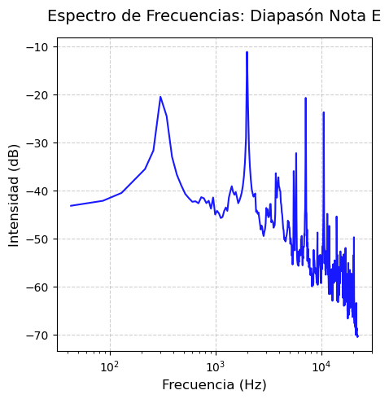

```python
plt.figure(figsize=(5,5), dpi=100)
plt.xscale('log')
plt.plot(frecuencia, decibelios, color='blue', alpha=0.9)
plt.title("Espectro de Frecuencias: Diapasón Nota E", fontsize=14, pad=15)
plt.xlabel("Frecuencia (Hz)", fontsize=12)
plt.ylabel("Intensidad (dB)", fontsize=12)
plt.grid(True, linestyle='--', alpha=0.6)
plt.show()
```

### 3.2 MEDIDAS PARA 20 DIAPASONES

De forma análoga al apartado anterior, se recogen en este los resultados de las mediciones de 20 diapasones para proceder posteriormente al ajuste por mínimos cuadrados.

[output not shown]

Procedemos a realizar el ajuste por mínimos cuadrados:

```python
anchuras = [6.00, 6.00, 6.00, 6.00, 6.35, 6.35, 6.50, 7.52, 6.50, 6.30, 7.30, 6.40, 6.26, 6.08, 7.20, 6.30, 6.90, 6.00, 4.75, 6.00]
longitudes = [114.00, 120.50, 123.60, 110.75, 129.50, 104.55, 106.00, 35.30, 136.70, 94.10, 33.60, 129.05, 116.46, 110.30, 51.70, 136.35, 98.00, 94.20, 170.00, 92.50]
N = [19, 9, 19, 17, 5, 3, 10, 9, 8, 6, 7, 11, 12, 13, 9, 11, 8, 9, 8, 7]
tiempo = [0.050, 0.028, 0.060, 0.044, 0.018, 0.007, 0.024, 0.002, 0.031, 0.011, 0.0017, 0.038, 0.035, 0.034, 0.004, 0.043, 0.017, 0.018, 0.063, 0.014]
```

```python
frecuencias_fourier = [378, 307, 317, 383, 284, 430, 428, 4082, 250, 513, 4100, 286, 335, 378, 2026, 253, 467, 507, 126.98, 500]
frecuencias_medidas = [N[i]/tiempo[i] for i in range (0, len(N))]
```

```python
x = []
for i in range (0, len(N)):
    x.append((0.1615*(anchuras[i])/1000)/(pow((longitudes[i]/1000), 2))) #Hacemos la conversión a metros
```

```python
res = stats.linregress(x, frecuencias_fourier)
print(f"R cuadrado: {res.rvalue**2:.6f}")
print(f"Ordenada en el origen: {res.intercept:.6f} m/s")
print(f"Error de la ordenada en el origen: {res.intercept_stderr:.6f} m/s")
print(f"Pendiente: {res.slope:.6f} m/s")
print(f"Error de la pendiente: {res.stderr:.6f} m/s")
```

```
R cuadrado: 0.996545
Ordenada en el origen: 51.320959 m/s
Error de la ordenada en el origen: 19.195819 m/s
Pendiente: 4038.925331 m/s
Error de la pendiente: 56.054543 m/s
```

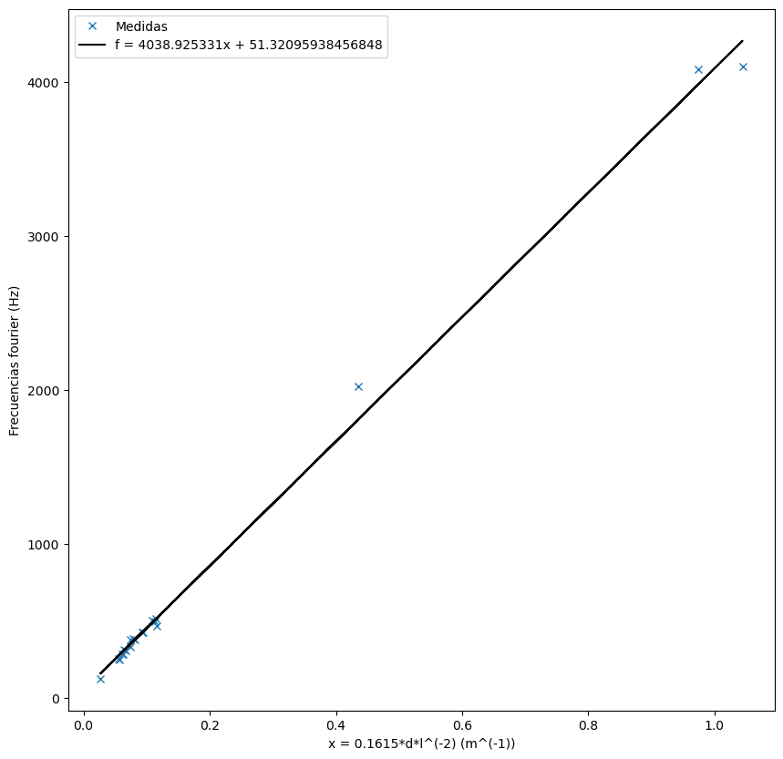

```python
def Lineal(x, A, B):
    y = np.multiply(A, x) + B
    return y
plt.figure(figsize=(10, 10))
plt.plot(x, frecuencias_fourier, 'x', label='Medidas')

fit_y = Lineal(x, res.slope, res.intercept)
plt.plot(x, fit_y, '-', label=f'f = {res.slope:.6f}x + {res.intercept}', color="black")
plt.xlabel("x = 0.1615*d*l^(-2) (m^(-1))")
plt.ylabel("Frecuencias fourier (Hz)")
plt.legend()

plt.show()
```

Entonces estimamos la velocidad del sonido en el aluminio como:

$$\boxed{v_{sonido} = 4038 \pm 56 \text{ }\frac{\text{m}}{\text{s}}}$$

podemos aplicar la ecuación ($2$) teniendo en cuenta la propagación de incertidumbres:

$$ u_E = \sqrt{\left({\frac{\partial E}{\partial v_s}}u_{v_s}\right)^2+\left({\frac{\partial E}{\partial \rho}}u_{\rho}\right)^2} = \sqrt{\left(2v_s\cdot\rho\cdot u_{v_s}\right)^2 + \left(v_s^2\cdot u_{\rho}\right)^2}$$

Obteniendo entonces el valor del módulo de Young:

$$\boxed{E = \overline{E} \pm u_E = 44.0 \pm 1.2 \text{ GPa}}$$

```python
v_s = res.slope
u_v_s = res.stderr
# Valores bibliográficos
DENSIDAD_ALUMINIO   = 2698.9 # [Rumble. J. R (2023)]
u_DENSIDAD_ALUMINIO = 0.1

E = DENSIDAD_ALUMINIO * (v_s**2)
u_E = ((2*v_s*DENSIDAD_ALUMINIO*u_v_s)**2 + (v_s**2 * u_DENSIDAD_ALUMINIO)**2)**0.5
print(f"Módulo de Young: E = {round(E / 10**9, 0)} ± {round(u_E / 10**9, 1)} GPa")
```

```
Módulo de Young: E = 44.0 ± 1.2 GPa
```